# **Assignment - 2: Basic Data Understanding**

This assignment will get you familiarized with Python libraries and functions required for data visualization.

## Part 1 - Loading data

### Import the following libraries:

- `numpy` with an alias name `np`,
- `pandas` with an alias name `pd`,
- `matplotlib.pyplot` with an alias name `plt`, and
- `seaborn` with an alias name `sns`.

```python
# Load the four libraries with their aliases
import numpy as np
import pandas as pd
import matplotlib.pyplot as plt
import seaborn as sns
```

### Using the files `train.csv` and `moviesData.csv`, peform the following:

- Load these file as `pandas` dataframes and store it in variables named `df` and `movies` respectively.
- Print the first ten rows of `df`.

```python
# Load the file as a dataframe
df = pd.read_csv("https://raw.githubusercontent.com/shala2020/shala2020.github.io/master/Lecture_Materials/Assignments/DataScience/L2/train.csv")
movies = pd.read_csv("https://raw.githubusercontent.com/shala2020/shala2020.github.io/master/Lecture_Materials/Assignments/DataScience/L2/moviesData.csv")
```

```python
# Print the first ten rows of df
df.head(10)
```

|  | Age | Attrition | BusinessTravel | DailyRate | Department | DistanceFromHome | Education | EducationField | EmployeeCount | EmployeeNumber | EnvironmentSatisfaction | Gender | HourlyRate | JobInvolvement | JobLevel | JobRole | JobSatisfaction | MaritalStatus | MonthlyIncome | MonthlyRate | NumCompaniesWorked | OverTime | PercentSalaryHike | PerformanceRating | RelationshipSatisfaction | StockOptionLevel | TotalWorkingYears | TrainingTimesLastYear | WorkLifeBalance | … |
| --- | --- | --- | --- | --- | --- | --- | --- | --- | --- | --- | --- | --- | --- | --- | --- | --- | --- | --- | --- | --- | --- | --- | --- | --- | --- | --- | --- | --- | --- | --- |
| 0 | 41 | 1 | Travel_Rarely | 1102 | Sales | 1 | 2 | Life Sciences | 1 | 1 | 2 | Female | 94 | 3 | 2 | Sales Executive | 4 | Single | 5993 | 19479 | 8 | Yes | 11 | 3 | 1 | 0 | 8 | 0 | 1 | … |
| 1 | 49 | 0 | Travel_Frequently | 279 | Research & Development | 8 | 1 | Life Sciences | 1 | 2 | 3 | Male | 61 | 2 | 2 | Research Scientist | 2 | Married | 5130 | 24907 | 1 | No | 23 | 4 | 4 | 1 | 10 | 3 | 3 | … |
| 2 | 37 | 1 | Travel_Rarely | 1373 | Research & Development | 2 | 2 | Other | 1 | 4 | 4 | Male | 92 | 2 | 1 | Laboratory Technician | 3 | Single | 2090 | 2396 | 6 | Yes | 15 | 3 | 2 | 0 | 7 | 3 | 3 | … |
| 3 | 33 | 0 | Travel_Frequently | 1392 | Research & Development | 3 | 4 | Life Sciences | 1 | 5 | 4 | Female | 56 | 3 | 1 | Research Scientist | 3 | Married | 2909 | 23159 | 1 | Yes | 11 | 3 | 3 | 0 | 8 | 3 | 3 | … |
| 4 | 27 | 0 | Travel_Rarely | 591 | Research & Development | 2 | 1 | Medical | 1 | 7 | 1 | Male | 40 | 3 | 1 | Laboratory Technician | 2 | Married | 3468 | 16632 | 9 | No | 12 | 3 | 4 | 1 | 6 | 3 | 3 | … |
| 5 | 32 | 0 | Travel_Frequently | 1005 | Research & Development | 2 | 2 | Life Sciences | 1 | 8 | 4 | Male | 79 | 3 | 1 | Laboratory Technician | 4 | Single | 3068 | 11864 | 0 | No | 13 | 3 | 3 | 0 | 8 | 2 | 2 | … |
| 6 | 59 | 0 | Travel_Rarely | 1324 | Research & Development | 3 | 3 | Medical | 1 | 10 | 3 | Female | 81 | 4 | 1 | Laboratory Technician | 1 | Married | 2670 | 9964 | 4 | Yes | 20 | 4 | 1 | 3 | 12 | 3 | 2 | … |
| 7 | 30 | 0 | Travel_Rarely | 1358 | Research & Development | 24 | 1 | Life Sciences | 1 | 11 | 4 | Male | 67 | 3 | 1 | Laboratory Technician | 3 | Divorced | 2693 | 13335 | 1 | No | 22 | 4 | 2 | 1 | 1 | 2 | 3 | … |
| 8 | 38 | 0 | Travel_Frequently | 216 | Research & Development | 23 | 3 | Life Sciences | 1 | 12 | 4 | Male | 44 | 2 | 3 | Manufacturing Director | 3 | Single | 9526 | 8787 | 0 | No | 21 | 4 | 2 | 0 | 10 | 2 | 3 | … |
| 9 | 36 | 0 | Travel_Rarely | 1299 | Research & Development | 27 | 3 | Medical | 1 | 13 | 3 | Male | 94 | 3 | 2 | Healthcare Representative | 3 | Married | 5237 | 16577 | 6 | No | 13 | 3 | 2 | 2 | 17 | 3 | 2 | … |

### Using the dataframe `df`, perform the following:

- Print the first five rows of the column `MonthlyRate`.
- Find out the details of the column `MonthlyRate` like mean, maximum value, minimum value, etc.

```python
# Print the first five rows of MonthlyRate
df['MonthlyRate'].head(10)
```

```
0    19479
1    24907
2     2396
3    23159
4    16632
5    11864
6     9964
7    13335
8     8787
9    16577
Name: MonthlyRate, dtype: int64
```

```python
# Find the details of MonthlyRate
df['MonthlyRate'].describe()
```

```
count     1028.000000
mean     14243.531128
std       7048.768076
min       2094.000000
25%       8259.750000
50%      14074.500000
75%      20342.250000
max      26999.000000
Name: MonthlyRate, dtype: float64
```

## Part 2 - Cleaning and manipulating data

### Using the dataframe `df`, peform the following:

- Check whether there are any missing values in `df`.
- If yes, drop those values and print the size of `df` after dropping these.

```python
# Check for missing values
print(df.describe().all)
# Drop the missing values
df.dropna(inplace=True)
# Print the size of df after dropping
print("Size of the Dataset : ",df.shape)
```

```
<bound method DataFrame.all of                Age    Attrition  ...  YearsWithCurrManager           ID
count  1028.000000  1028.000000  ...           1028.000000  1028.000000
mean     36.999027     0.167315  ...              4.141051   513.500000
std       9.444297     0.373439  ...              3.608460   296.902341
min      18.000000     0.000000  ...              0.000000     0.000000
25%      30.000000     0.000000  ...              2.000000   256.750000
50%      36.000000     0.000000  ...              3.000000   513.500000
75%      43.000000     0.000000  ...              7.000000   770.250000
max      60.000000     1.000000  ...             17.000000  1027.000000

[8 rows x 27 columns]>
Size of the Dataset :  (1028, 34)
```

### Using the dataframe `df`, peform the following:

- Add another column named `MonthRateNew` in `df` by subtracting the mean from `MonthlyRate` and dividing it by standard deviation.

```python
# Add a column named MonthRateNew
x = (df['MonthlyRate']-df['MonthlyRate'].mean())/df['MonthlyRate'].std()
df['MonthlyRateNew'] = x
df['MonthlyRateNew'].head(5)
```

```
0    0.742749
1    1.512813
2   -1.680795
3    1.264827
4    0.338849
Name: MonthlyRateNew, dtype: float64
```

### Using the dataframe `movies`, perform the following:

- Check whether there are any missing values in `movies`.
- Find out the number of observations/rows having any of their features/columns missing.
- Drop the missing values and print the size of `movies` after dropping these.
- Instead of dropping the missing values, replace the missing values by their mean (or some suitable value).

```python
# Check for missing values
movies_isnull = movies.isnull()
# Drop the missing values
print("Number of missing values for Movies : ",sum(movies_isnull.sum()))
movies.dropna(inplace=True)
# Replace the missing values
# You can use SimpleImputer of sklearn for this
```

[output not shown]

```
Number of missing values for Movies :  73
```

## Part 3 - Visualizing data

### Visualize the `df` by drawing the following plots:

- Plot a histogram of `Age` and find the range in which most people are there.
- Modify the histogram of `Age` by adding 30 bins.
- Draw a scatter plot between `Age` and `Attrition` and suitable labels to the axes. Find out whether people more than 50 years are more likely to leave the company. (`Attrition` = 1 means people have left the company).

```
(Text(0.5, 0, 'Age'), Text(0, 0.5, 'Attrition'))
```

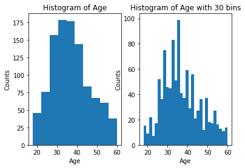

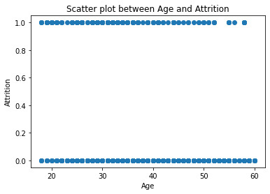

```python
# Plot and modify the histogram of Age
plt.figure()
plt.subplot(121)
plt.hist(df['Age'])
plt.title('Histogram of Age')
plt.xlabel("Age"),plt.ylabel("Counts")
plt.subplot(122)
plt.hist(df['Age'],bins=30)
plt.xlabel("Age"),plt.ylabel("Counts")
plt.title('Histogram of Age with 30 bins')
# Draw a scatter plot between Age and Attrition
plt.figure()
plt.scatter(df["Age"],df["Attrition"])
plt.title("Scatter plot between Age and Attrition")
plt.xlabel("Age"),plt.ylabel("Attrition")
```

The Histogram shows that most of the people are between Age 30-40 years.

The scatter plot of Age vs Attrition shows that people of Age > 50 are less likely to leave the company.

### Visualize the `df` by following the steps given below:

- Get a series containing counts of unique values of `Attrition`.
- Draw a countplot for `Attrition` using `sns.countplot()`.

```
Value counts for Attrition data :
0    856
1    172
Name: Attrition, dtype: int64
```

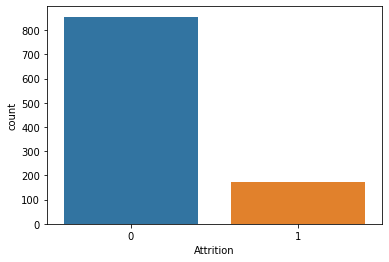

```python
# Get a series of counts of values of Attrition
print("Value counts for Attrition data :")
print(df["Attrition"].value_counts())

# Draw a countplot for Attrition
# You may use countplot of seaborn for this
plt.figure()
sns.countplot(df["Attrition"])
```